# test for hw1

Yige Bian

2023-9-18

# 1 Problem 1

```r
library(moderndive)
data("early_january_weather")
```

The dataset ‘early_january_weather’ has 358 rows and 15 columns. Variables in the dataset are origin, year, month, day, hour, temp, dewp, humid, wind_dir, wind_speed, wind_gust, precip, pressure, visib, time_hour.

- The variable `origin` has class character
- The variable `year` has class integer
- The variable `month` has class integer
- The variable `day` has class integer
- The variable `hour` has class integer
- The variable `temp` has class numeric
- The variable `dewp` has class numeric
- The variable `humid` has class numeric
- The variable `wind_dir` has class numeric
- The variable `wind_speed` has class numeric
- The variable `wind_gust` has class numeric
- The variable `precip` has class numeric
- The variable `pressure` has class numeric
- The variable `visib` has class numeric
- The variable `time_hour` has class POSIXct, POSIXt.

The mean temperature is 39.5821229

```r
Sys.setlocale("LC_TIME", "English")
```

```
## [1] "English_United States.1252"
```

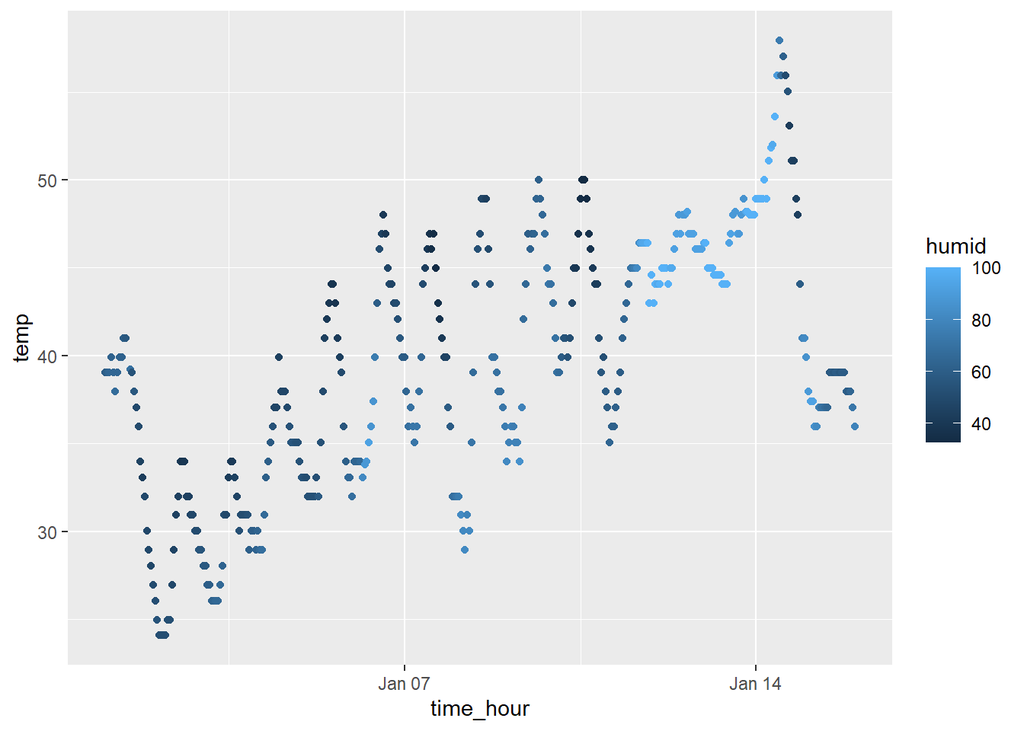

```r
ggplot(early_january_weather, aes(x = time_hour, y = temp, color=humid)) + geom_point()
```

```r
ggsave("scatter_plot.pdf", height = 4, width = 6)
```

The scatter plot illustrates that, from January 1st to January 15th, a noticeable upward trend in temperature fluctuations can be observed. The temperature during different times of the day follows a similar pattern of change, and overall, the average temperature continues to rise. In the first few days of January, the humidity is relatively low. Starting from January 6th, there are intermittent periods of increased humidity. It’s worth noting that from January 11th to January 14th, the humidity is particularly high, and during these days, the daily temperature fluctuations are relatively small.

# 2 Problem 2

```r
set.seed(1)

samp_df = tibble(
  vec_random = rnorm(10),
  vec_logical = vec_random > 0,
  vec_char = c("1", "2", "3", "4", "5", "6", "7", "8", "9", "10"),
  vec_factor = factor(c("high", "med", "samll", "high", "med", "med", "samll", "samll", "high", "med"))
)
```

```r
mean(pull(samp_df,vec_random))
```

```
## [1] 0.1322028
```

```r
mean(pull(samp_df,vec_logical))
```

```
## [1] 0.6
```

```r
mean(pull(samp_df,vec_char))
```

```
## [1] NA
```

```r
mean(pull(samp_df,vec_factor))
```

```
## [1] NA
```

```r
mean(as.numeric(pull(samp_df,vec_char)))
```

```
## [1] 5.5
```

```r
as.numeric(pull(samp_df,vec_factor))
```

```
##  [1] 1 2 3 1 2 2 3 3 1 2
```